# Intuitions about the shortest paths on planes and spheres, data set 1 (adults, y/n response)

Matthew Jordan, Yuval Hart, Moira R. Dillon

2018-10-29

# 1 Background

## 1.1 Introduction

The concept of a line, i.e., the shortest path between two points on a surface, is essential to our formal systems of geometry. Prior work has suggested that, regardless of formal education, adults have some basic intuitions about points and lines on both planar and spherical surfaces, although planar intuitions appear to be stronger (e.g., Izard et al., 2011). Further work has suggested that planar intuitions are not perfect (e.g., Dillon & Spelke, 2018; Hart et al., 2018) and that educated adults’ explicit geometric reasoning about the properties of points, lines, and planar figures may be affected by geometric information that is irrelevant to a particular judgment. For example, adults’ judgments about the sum of the internal angles of a planar triangle is scale dependent, whereas the formal rule describing this sum is scale independent (Euclid, 1990/300 BCE; Hart et al., 2018).

The present study explores educated adults’ intuitions about the shortest path between two points on pictures of planes and spheres. It examines whether the judgment about a path’s linearity in a picture of a sphere is affected by whether that same path is also a straight line on a picture of plane. It further examines how factors such as sphere size, line length, and magnitude of the sphere’s rotation, as presented in the picture, further affect this judgment. This study thus aims to evaluate, in our geometric intuitions, both a planar bias as well as an influence of geometric information that is not relevant to a linearity judgment in our formal systems of geometry.

## 1.2 Methods

- Forty-eight adults were included in this study. They were shown pictures of paths on planes and spheres and asked whether the path depicts the shortest distance between the two points.
- An additional 26 adults participated in this study, but were excluded because of not meeting preregistered inclusion criteria (random responding: 15; technical failure: 11). One additional participant was excluded, who explicitly expressed that they did not follow the task directions.
- Photos differed by surface (plane vs. sphere), planar linearity (line vs. curve), and spherical linearity (geodesic vs. arc) for 8 total categories.
- Participants saw 28 randomly selected pictures from each category in a random order.
- Pictures also differed in path length, sphere size, sphere rotation, and each had a random orientation (avoiding +/-10° of the horizontal and vertical).
- Below are examples of stimuli and an explanation of the difference between lines, curves, geodesics, and arcs.

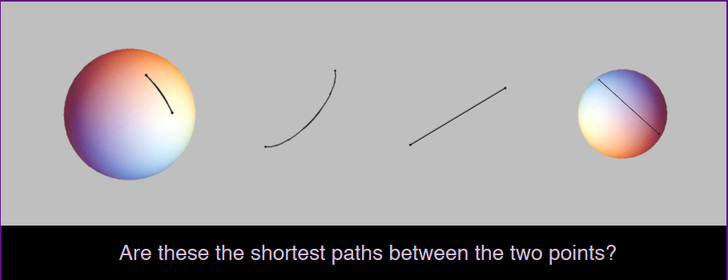

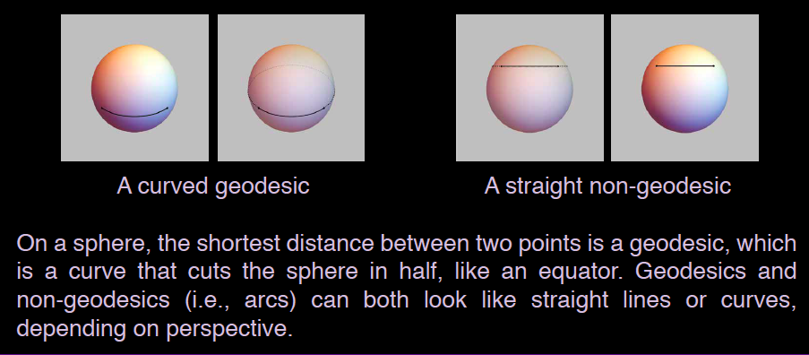

## 1.3 Conditions

There are 8 categories of stimuli. Half of these are spheres and half are planes; the planar images are identical to the spherical ones with the sphere made fully transparent. Collapsing across all sphere/plane pairs, therefore, there are 4 conditions of stimuli:

- Geodesic Line (geoline)
  - A line along the equator of the sphere
- Geodesic Curve (geocurve)
  - Obtained by rotating an equator curve so that it no longer appears along the equator
- Arc Line (arcline)
  - A line obtained by connecting two non-equator points on the sphere at eye-level
- Arc Curve (arccurve)
  - A curve connecting two non-equator points without being a geodesic

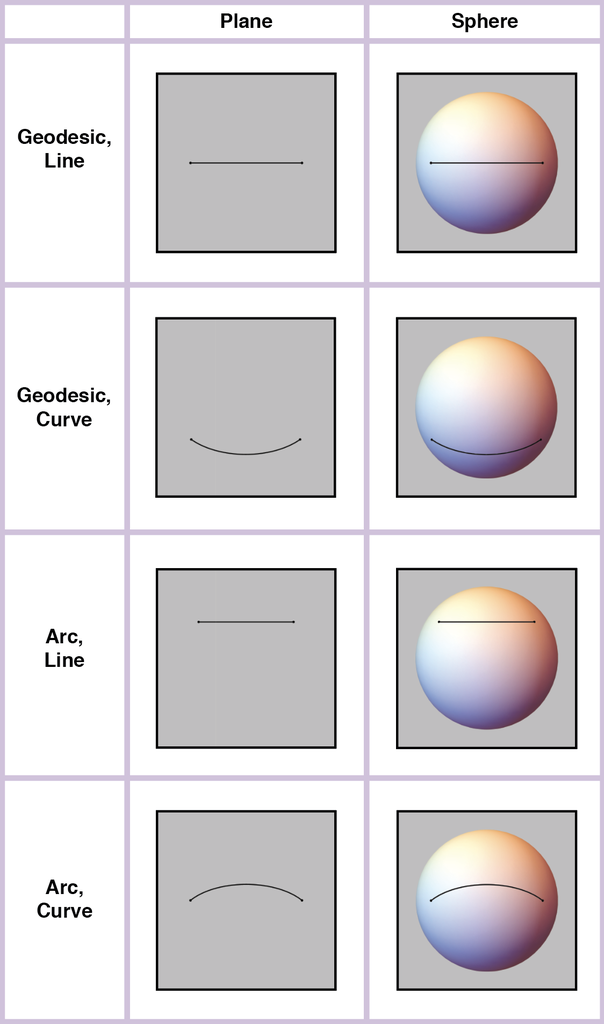

Let’s examine each of these in turn, and explore the parameters that go into them.

### 1.3.1 Geodesic Line

The Geo Line is the simplest of the four categories, since it consists of straight lines along the equator of the sphere. There are therefore two parameters here: `size` and `separation`.

`size` controls the radius of the sphere, which is defined like this:

```r
# Size = {0, 1, 2, 3}
radius <- function(size){
   return(2*2^(size/3))
}
```

`separation` establishes the distance between the two points on the sphere. We start by defining the angle between the two points–the angle starts at $\frac{\pi}{9}$ radians then increases log-linearly until it hits $\frac{2\pi}{3}$ radians.

```r
# Separation = {0, 1, ...., 6}
min_angle <- function(separation) {
  return(-pi/2 - (pi/18)*6^(separation/6))
}

max_angle <- function(separation) {
  return(-pi/2 + (pi/18)*6^(separation/6))
}
```

The curve runs along the equator of the sphere, starting at `min_angle` and ending at `max_angle`. The start and endpoints are therefore defined as follows:

```r
# Size = {0, 1, 2, 3}
# Separation = {0, 1, ..., 6}
left_point <- function(size, separation){
  left_x <- cos(min_angle(separation))
  left_y <- sin(min_angle(separation))
  return(radius(size)*c(left_x, left_y, 0))
}

right_point <- function(size, separation){
  right_x <- cos(max_angle(separation))
  right_y <- sin(max_angle(separation))
  return(radius(size)*c(right_x, right_y, 0))
}
```

With this in mind, we can define the distance between the two points in terms of their angular separation (in radians) and the length of the line that joins them:

```r
# Separation = {0, 1, ..., 6}
point_sep_rad <- function(separation){
  return(max_angle(separation) - min_angle(separation))
}

length_gl <- function(size, separation){
  return(point_sep_rad(separation)*radius(size))
}
```

Moreover, the height of all these points (i.e. their z-coordinate) is zero.

```r
height_gl <- 0
```

With 4 possible sizes and 7 possible separations, this yields a total of 28 Geodesic Line pictures. But this just includes the spherical conditions; the planar trials are generated by making the underlying spheres transparent, which leads to a total of 56 images for this category.

### 1.3.2 Geodesic Curve

The geodesic curves are nearly identical to the geodesic lines, except the sphere is rotated by an amount specified by a new variable, `pull`, so that the path now appears curved instead of straight.

The calculation for the rotation angle is done as follows. We specify a `back_point`, which is a point that lies on the side of the sphere that points away from the viewer. If `pull` is positive, this point is below the $x$-$y$ plane. If `pull` is negative, it goes above the plane.

```r
# Size = {0, 1, 2, 3}
# Pull = {-5, ..., -1, 1, ... 5}
back_point <- function(size, pull){
  back_y <- cos(pull*pi/15)
  back_z <- -sin(pull*pi/15)
  return(radius(size)*c(0, back_y, back_z))
}
```

We then rotate the sphere by an amount which would result in this `back_point` being aligned at the same height as the `left_point` and `right_point` we defined before. Picture a sphere with one point marked on the backside, directly opposite your viewing perspective, but above the equator. Imagine two additional points along the equator on your side of the sphere. By how much would you need to rotate the sphere in order for these three points to be at the same height?

The answer is somewhat tricky. We need to construct a plane that connects these three points, then determine the angle between the plane’s normal vector and the z-axis. This angle becomes our rotation angle. We therefore define `norm_vec` and `rot_angle` as follows:

```r
# Size = {0, 1, 2, 3}
# Separation = {0, 1, ..., 6}
# Pull = {-5, ..., -1, 1, ..., 5}
norm_vec <- function(size, separation, pull){
  left_pt <- left_point(size, separation)
  right_pt <- right_point(size, separation)
  back_pt <- back_point(size, pull)
  vec_1 <- (left_pt - back_pt)
  vec_2 <- (right_pt - back_pt)
  normal <- pracma::cross(vec_1, vec_2)
  return(normal/Norm(normal)) # Unit normal
}

rot_angle <- function(size, separation, pull, spin = NA_integer_){
  normal <- norm_vec(size, separation, pull)
  angle <- acos(dot(normal, c(0, 0, 1)))
  ifelse(is.na(spin), angle, 1.7*spin*angle)
}
```

The height of the points is therefore:

```r
rot_matrix <- function(size, separation, pull, spin = NA_integer_){
  angle <- rot_angle(size, separation, pull, spin)
  return(rot.matrix(c(0, 0), theta = angle, rads = TRUE))
}

height_gc <- function(size, separation, pull){
  rotated <- rot_matrix(size, separation, pull) %*%
    left_point(size, separation)
  return(rotated[3])
}
```

And the line length is:

```r
length_gc <- function(size, separation){
  return(point_sep_rad(separation)*radius(size))
}
```

### 1.3.3 Arc Line

The arc lines are paths on the sphere which, if the sphere were to disappear, would look like straight lines. These paths are not located on the equator, which makes them arcs, not geodesics. If these paths were to continue all the way around the sphere, they’d cut off a spherical cap.

These are generated by once again specifying a `back_point` on the opposite side of the sphere as the viewer.

```r
chord_length <- function(size, pull){
  vector <- radius(size)*c(0, -1, 0) - back_point(size, pull)
  return(Norm(vector))
}

height_al <-  function(size, pull){
  length <- radius(size)^2 - (chord_length(size, pull)/2)^2
  return(sign(pull)*sqrt(length))
}
```

The length of the curve is:

```r
length_al <- function(size, separation, pull){
  new_radius <- chord_length(size, pull)/2
  return(new_radius*point_sep_rad(separation))
}
```

### 1.3.4 Arc Curve

This function takes two points along the equator and creates a plane between those two points and the `back_point`, then draws a path at the intersection of that plane and the sphere. If `spin = 0` then this is the final output, but if `spin = 1` then this curve is rotated by 1.7 times the angle between the plane and the z-axis.

```r
# Spin = {0, 1.7}
height_ac <- function(size, separation, pull, spin){
  rotated <- rot_matrix(size, separation, pull, spin) %*%
    left_point(size, separation)
  return(rotated[3])
}
```

The length of the curve is slightly tricky to calculate, but it involves knowing the formula for the intersection of a plane and a sphere. The main tricky step is identifying the point at the center of the circle of intersection of the plane and the sphere.

```r
length_ac <- function(size, separation, pull){
  left_pt <- left_point(size, separation)
  right_pt <- right_point(size, separation)
  norm_vec <- norm_vec(size, separation, pull)
  plane_constant <- dot(left_pt, norm_vec)
  center_pt <- plane_constant*norm_vec
  to_left <- left_pt - center_pt
  to_right <- right_pt - center_pt
  new_radius <- Norm(to_left)
  arc_length <- acos(dot(to_left, to_right)/(Norm(to_left))^2)
  return(new_radius*arc_length)
}
```

# 2 Results

Read in the data and transform to the proper format.

```r
IGEO_data <- read_csv("data/IGEO_data.csv", col_types = cols())

IGEO_data %<>%
  select(
    Subject.No., Version, order, image, Surface, Planar.Straight,
    Spherical.Straight, Line.Length, Response, rt
    ) %>%
  set_names(
    x = .,
    nm = c("subject_no", "version", "order", "image", "surface",
  "planar", "spherical", "line_length", "response", "reaction_time")
    ) %>%
  mutate_at(
  .vars = c("subject_no", "version", "order", "surface",
  "planar", "spherical", "response"),
  .funs = factor
  ) %>%
  mutate(response = factor(response, labels = c("incorrect", "correct"))) %>%
  arrange(surface, desc(planar), desc(spherical))
```

We now add the relevant information about point separation, rotation angle, height, size, and other features of the images. This is rather lengthy, but you can click to expand.

**IGEO Data Specs**

```r
# Get the info about size, separation, pull, spin
IGEO_data %<>%
  mutate(image_stripped = str_remove_all(image,
    "gPlane_|Plane_|Sphere_|gSphere_|_.jpg")) %>%
  separate(
    col = image_stripped,
    into = c("size", "separation", "pull", "spin"),
    sep = "_",
    remove = TRUE
  ) %>%
  mutate(pull = str_replace(pull, fixed("(Neg)"), "-")) %>%
  mutate_at(
    .vars = c("size", "separation", "pull", "spin"),
    .funs = as.numeric
  )

# Load into the data the specifics about the height,
# line length, rotation angle, etc.
IGEO_data %<>%
  mutate(
    pull = replace_na(pull, 0),
    point_sep_rad = point_sep_rad(separation),
    rotation_angle = case_when(
      planar == "line" & spherical == "arc" ~ 0,
      TRUE ~ pmap(
        .l = list(size, separation, pull, spin),
        .f = rot_angle
        ) %>% unlist()
      ),
    height = by_case(
      col_1 = planar, col_2 = spherical,
      gl = 0,
      gc = pmap(.l = list(size, separation, pull), .f = height_gc) %>% unlist(),
      al = map2(.x = size, .y = pull, .f = height_al) %>% unlist(),
      ac = pmap(.l = list(size, separation, pull, spin), .f = height_ac) %>% unlist()
      ),
    height = abs(height)/radius(size),
    line_length = by_case(
      col_1 = planar, col_2 = spherical,
      gl = map2(.x = size, .y = separation, .f = length_gl) %>% unlist(),
      gc = map2(.x = size, .y = separation, .f = length_gc) %>% unlist(),
      al = pmap(.l = list(size, separation, pull), .f = length_al) %>% unlist(),
      ac = pmap(.l = list(size, separation, pull), .f = length_ac) %>% unlist()
      )
    ) %>%
  select(everything(), response, reaction_time)

IGEO_data %>% write_csv("data/IGEO_data_updated.csv")
```

## 2.1 Descriptives

Let’s examine the descriptives. First, a simple question: how did participants, in general, perform on this task?

```r
num_trials <- IGEO_data %>% nrow()

# Get the overall correct proportion
all_trials <- IGEO_data %>%
  group_by(response) %>%
  summarise(
    count = n(),
    percentage = round(count/(num_trials), 3)
    )

# Summarize
all_trials %>%
  kable(.)
```

| response | count | percentage |
| --- | --- | --- |
| incorrect | 3088 | 0.287 |
| correct | 7664 | 0.713 |

We see that 71% of all responses were correct. Let’s break this number down by category to see how participants did on each of the 8 types of stimuli.

```r
# Break results down by category
IGEO_descriptives <- IGEO_data %>%
  mutate(response = as.numeric(response) - 1) %>%
  group_by(surface, spherical, planar) %>%
  summarise(percentage_correct = mean(response)) %>%
  mutate(condition = sprintf("%s_%s_%s", surface, spherical, planar)) %>%
  select(everything()) %>%
  ungroup() %>%
  arrange(surface, desc(planar), desc(spherical))

# Summarize
IGEO_descriptives %>%
  select(condition, percentage_correct) %>%
  kable(.)
```

| condition | percentage_correct |
| --- | --- |
| plane_geo_line | 0.9605655 |
| plane_arc_line | 0.9672619 |
| plane_geo_curve | 0.8318452 |
| plane_arc_curve | 0.8102679 |
| sphere_geo_line | 0.7700893 |
| sphere_arc_line | 0.3526786 |
| sphere_geo_curve | 0.6636905 |
| sphere_arc_curve | 0.3459821 |

Let’s plot these descriptive results.

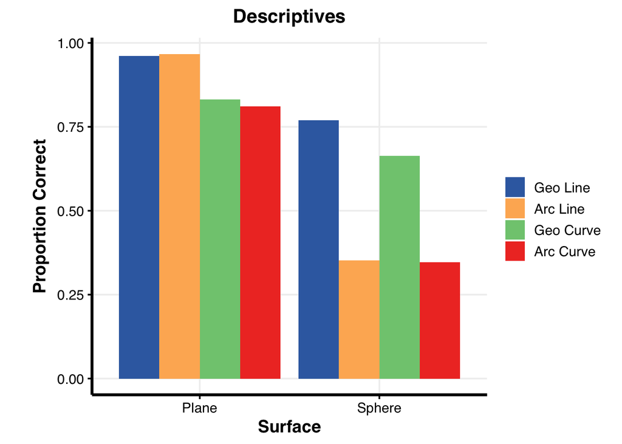

```r
my_labs <- function(){
  labs(
    x = "Surface",
    y = "Proportion Correct",
    fill = " ",
    title = "Descriptives"
  )
}

IGEO_descriptives %>%
  mutate(
    condition = sprintf("%s %s", str_to_title(spherical), str_to_title(planar)),
    condition = factor(condition, levels = unique(condition))
    ) %>%
  ggplot(data = .,
    aes(x = str_to_title(surface), y = percentage_correct, fill = condition)) +
  geom_bar(position = position_dodge(width = NULL), stat = "identity") +
  my_labs() + IGEO_theme() + IGEO_fill()
```

Note that in all categories, participants answer correctly on average, except for arcs on the sphere. Participants say too frequently that the paths are the shortest between the two points. We will explore later whether this error is caused by an overall bias for participants to say “yes” when asked if a path on a sphere is the shortest.

# 3 Analysis

Let’s run some regressions! We first evaluate whether participants’ responses were above chance. Then, we run our preregistered analyses (Models 1 & 2). For Model 1, we include an additional post-hoc analysis (Model 1b), where we explore whether the results we observe in Model 1 can be explained by a “yes”-bias. We also include a post-hoc version of Model 2, in which we substitute one variable (a mathematical property of the stimuli) for another one (a pictorial property) that is closely related.

## 3.1 Above Chance Model

The model is a simple binomial regression to see whether, overall, participants perform better than chance.

```r
# All trials together
model_above_chance <- IGEO_data %>%
  glmer(
    data = .,
    response ~ (1 | subject_no),
    family = binomial(link = "logit"),
    glmerControl(optimizer = "optimx", optCtrl = list(method = "nlminb"))
    )

# Take a look
model_above_chance %>%
  tidy() %>%
  filter(term == "(Intercept)") %>%
  mutate(term = "Intercept") %>%
  mutate(
    p_value = "0.0000",
    p_value_clean = clean_p_val(p.value),
    p_value_star = stars.pval(p.value)
  ) %>%
  rename(
    "std_error" = std.error,
    "log_odds" = estimate
    ) %>%
  select(-p.value, -group) %>%
  kable(.)
```

| term | log_odds | std_error | statistic | p_value | p_value_clean | p_value_star |
| --- | --- | --- | --- | --- | --- | --- |
| Intercept | 0.9133273 | 0.0296572 | 30.79616 | 0.0000 | p < 0.001 | *** |

Overall, then, performance was significantly above chance. Let’s now split this up by category to see how participants performed on each of the 8 types of questions.

```r
# Split up by category
model_above_chance_split <- IGEO_data %>%
  group_by(surface, spherical, planar) %>%
  do(
    above_chance = glmer(
      data = .,
      response ~ (1 | subject_no),
      family = binomial(link = "logit"),
      glmerControl(optimizer = "optimx", optCtrl = list(method = "nlminb"))
      )
    )

# Look at results
model_above_chance_split %>%
  tidy(above_chance, conf.int = TRUE) %>%
  ungroup() %>%
  filter(term == "(Intercept)") %>%
  mutate(
    p_value = round(p.value, 4),
    p_value_clean = clean_p_val(p.value),
    p_value_star = gtools::stars.pval(p_value),
    condition = sprintf("%s_%s_%s", surface, spherical, planar)
  ) %>%
  arrange(surface, desc(planar), desc(spherical)) %>%
  mutate(probability = 1/(1 + exp(-estimate))) %>%
  rename(
    "std_error" = std.error,
    "log_odds" = estimate,
    "conf_lower" = conf.low,
    "conf_upper" = conf.high
    ) %>%
  select(condition, everything(), -term, -surface, -planar,
    -spherical, -group, -p.value) %>%
  kable(.)
```

| condition | log_odds | std_error | statistic | conf_lower | conf_upper | p_value | p_value_clean | p_value_star | probability |
| --- | --- | --- | --- | --- | --- | --- | --- | --- | --- |
| plane_geo_line | 3.5895063 | 0.2633280 | 13.631311 | 3.073393 | 4.1056197 | 0.0000 | p < 0.001 | *** | 0.9731300 |
| plane_arc_line | 3.6905611 | 0.2554117 | 14.449458 | 3.189963 | 4.1911589 | 0.0000 | p < 0.001 | *** | 0.9756497 |
| plane_geo_curve | 1.5987614 | 0.0729333 | 21.920870 | 1.455815 | 1.7417081 | 0.0000 | p < 0.001 | *** | 0.8318452 |
| plane_arc_curve | 1.4791186 | 0.0845213 | 17.499950 | 1.313460 | 1.6447773 | 0.0000 | p < 0.001 | *** | 0.8144394 |
| sphere_geo_line | 3.7407753 | 0.8269931 | 4.523345 | 2.119899 | 5.3616521 | 0.0000 | p < 0.001 | *** | 0.9768146 |
| sphere_arc_line | -1.6350114 | 0.5397151 | -3.029397 | -2.692834 | -0.5771891 | 0.0025 | p < 0.01 | ** | 0.1631450 |
| sphere_geo_curve | 0.9153285 | 0.2078025 | 4.404799 | 0.508043 | 1.3226139 | 0.0000 | p < 0.001 | *** | 0.7140893 |
| sphere_arc_curve | -0.8613361 | 0.2182804 | -3.946007 | -1.289158 | -0.4335144 | 0.0001 | p < 0.001 | *** | 0.2970603 |

We note that the performance is significantly different from chance in all cases, with `p < 0.001` in all cases except`sphere_arc_line`, which has `p < 0.01`. We note as well that, as seen from the descriptives, the performance for `sphere_arc_line` and `sphere_arc_curve` were both significantly below chance.

## 3.2 Model 1

Our first preregistered model examines the main effects of the surface (plane vs. sphere), the planar linearity (line vs. curve), and the spherical linearity (geodesic vs. arc), as well as all of the possible interaction effects among these variables.

### 3.2.1 Preditions

In our preregistered hypotheses, we predicted the following main effects:

- Surface: responses will be more accurate for pictures of planes then pictures of spheres
- Planar linearity: responses will be more accurate for lines than curves
- Spherical linearity: responses will be more accurate for geodesics than arcs

In addition, we predicted a significant interaction between the surface and spherical linearity. While there might be no difference between responses to geodesics versus arcs on pictures of planes, responses might be more accurate for geodesics versus arcs on pictures of spheres. Finally, we predicted a three-way interaction: arc curves should be more difficult to identify on spheres than on planes.

### 3.2.2 Running the Model

```r
model_1 <- glmer(
  data = IGEO_data,
  formula = response ~ surface * planar * spherical + (1 + surface + planar | subject_no),
  family = binomial(link = "logit"),
  glmerControl(optimizer = "optimx", optCtrl = list(method = "nlminb"))
  )

# Show the results
clean_IGEO_model(
  model = model_1,
  col_names = c("Intercept", "Surface", "Planar", "Spherical",
    "Surface x Planar", "Surface x Spherical", "Planar x Spherical",
    "Surface x Planar x Spherical")
)
```

| term | log_odds | std_error | statistic | conf_lower | conf_upper | p_value | p_value_clean | p_value_star |
| --- | --- | --- | --- | --- | --- | --- | --- | --- |
| Intercept | 1.4836723 | 0.0848486 | 17.486107 | 1.3173720 | 1.6499726 | 0.0000 | p < 0.001 | *** |
| Surface | -2.1215392 | 0.1029507 | -20.607336 | -2.3233188 | -1.9197595 | 0.0000 | p < 0.001 | *** |
| Planar | 2.0297691 | 0.1794651 | 11.310105 | 1.6780240 | 2.3815142 | 0.0000 | p < 0.001 | *** |
| Spherical | 0.1491887 | 0.1012217 | 1.473880 | -0.0492023 | 0.3475796 | 0.1405 | 0.141 |  |
| Surface x Planar | -2.0202462 | 0.1898766 | -10.639785 | -2.3923975 | -1.6480949 | 0.0000 | p < 0.001 | *** |
| Surface x Spherical | 1.1696829 | 0.1300268 | 8.995708 | 0.9148351 | 1.4245308 | 0.0000 | p < 0.001 | *** |
| Planar x Spherical | -0.3439218 | 0.2306129 | -1.491338 | -0.7959147 | 0.1080712 | 0.1359 | 0.136 |  |
| Surface x Planar x Spherical | 0.9125584 | 0.2603266 | 3.505437 | 0.4023276 | 1.4227891 | 0.0005 | p < 0.001 | *** |

Moreover, as expected, there is a significant `Surface x Planar x Spherical` effect, indicating that an arc curve on a sphere is more difficult to identify than an arc curve on a plane.

### 3.2.3 Marginal Means

We now examine the model’s predicted values for each of the 8 conditions, i.e., the marginal means.

```r
# Estimated Marginal Means
model_1_predicted <- emmeans(
  object = model_1,
  specs = ~ surface * planar * spherical ,
  type = "response"
  )

model_1_predicted_clean <- clean_IGEO_emmeans(model_1_predicted)

model_1_predicted_clean %>%
  kable()
```

| surface | planar | spherical | probability | std_error | conf_lower | conf_upper |
| --- | --- | --- | --- | --- | --- | --- |
| plane | line | geo | 0.9650651 | 0.0055479 | 0.9541912 | 0.9759390 |
| plane | line | arc | 0.9710678 | 0.0049405 | 0.9613843 | 0.9807513 |
| plane | curve | geo | 0.8365612 | 0.0119919 | 0.8130570 | 0.8600654 |
| plane | curve | arc | 0.8151266 | 0.0127863 | 0.7900655 | 0.8401877 |
| sphere | line | geo | 0.7788822 | 0.0158259 | 0.7478635 | 0.8099009 |
| sphere | line | arc | 0.3478861 | 0.0195722 | 0.3095247 | 0.3862476 |
| sphere | curve | geo | 0.6639629 | 0.0131975 | 0.6380958 | 0.6898300 |
| sphere | curve | arc | 0.3457289 | 0.0132930 | 0.3196747 | 0.3717831 |

Here is a plot of these model predictions.

**Model 1 plot code**

```r
my_labs <- function(){
  labs(
    x = "Surface",
    y = "Predicted Proportion Correct",
    fill = " ",
    title = "Model 1 Predictions"
  )
}

model_1_plot <- model_1_predicted_clean %>%
   mutate(
      condition = sprintf("%s %s", str_to_title(spherical), str_to_title(planar)),
      condition = factor(condition, levels = unique(condition))
    ) %>%
  ggplot(data = ., aes(x = str_to_title(surface), y = probability, fill = condition)) +
  geom_bar(position = position_dodge(width = NULL), stat = "identity") +
  geom_errorbar(aes(ymin = conf_lower, ymax = conf_upper),
    position = position_dodge(0.9), width = 0.2, size = 0.4) +
  my_labs() + IGEO_theme() + IGEO_fill()
```

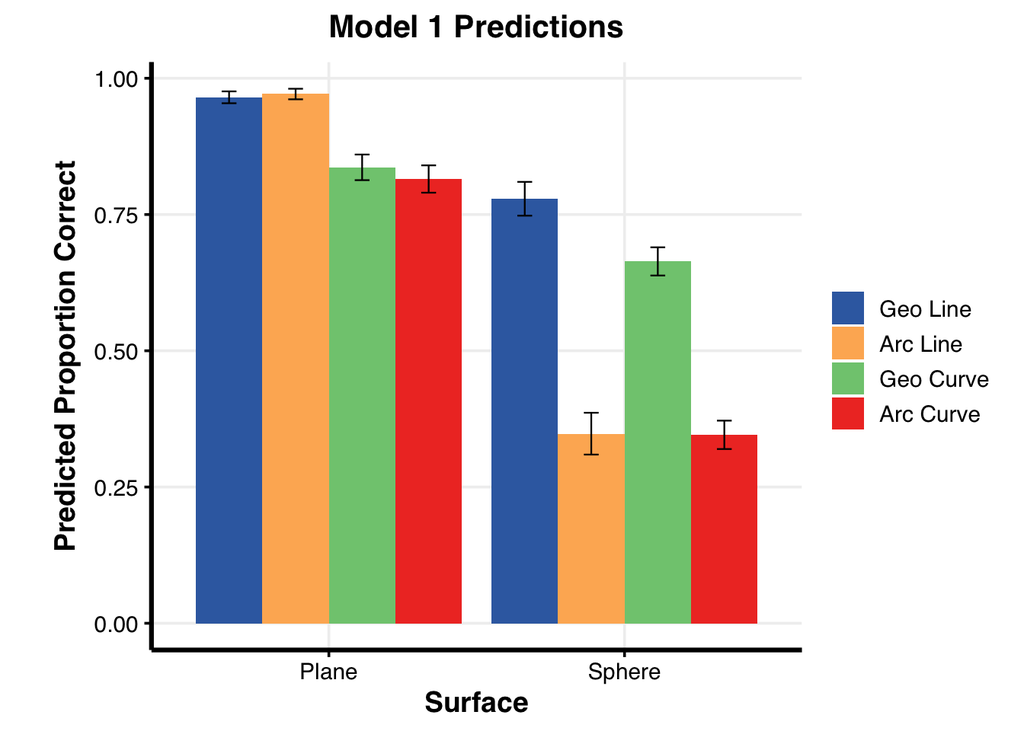

```r
model_1_plot
```

This plot looks a great deal like the graph of the descriptives for each, but it was generated by an explanatory model which we can use to better understand these data.

### 3.2.4 Contrasts

We now look at the contrasts in order to explore which differences between categories are significant. All contrasts are holm-adjusted to correct for multiple comparisons.

```r
# Compute contrasts
contrast(
  object = model_1_predicted,
  by = c("surface"),
  method = "pairwise",
  adjust = "holm"
  ) %>%
  clean_IGEO_contrasts()
```

| surface | contrast | odds_ratio | std_error | p_value | p_value_clean | p_value_star |
| --- | --- | --- | --- | --- | --- | --- |
| plane | curve,arc / line,arc | 0.1313659 | 0.0235756 | 0.0000 | p < 0.001 | *** |
| plane | curve,arc / curve,geo | 0.8614066 | 0.0871931 | 0.2810 | 0.281 |  |
| plane | curve,arc / line,geo | 0.1596078 | 0.0268830 | 0.0000 | p < 0.001 | *** |
| plane | line,arc / curve,geo | 6.5573097 | 1.1853404 | 0.0000 | p < 0.001 | *** |
| plane | line,arc / line,geo | 1.2149867 | 0.2517613 | 0.3473 | 0.347 |  |
| plane | curve,geo / line,geo | 0.1852874 | 0.0314646 | 0.0000 | p < 0.001 | *** |
| sphere | curve,arc / line,arc | 0.9905223 | 0.0975056 | 0.9229 | 0.923 |  |
| sphere | curve,arc / curve,geo | 0.2674369 | 0.0218247 | 0.0000 | p < 0.001 | *** |
| sphere | curve,arc / line,geo | 0.1500133 | 0.0155126 | 0.0000 | p < 0.001 | *** |
| sphere | line,arc / curve,geo | 0.2699958 | 0.0266417 | 0.0000 | p < 0.001 | *** |
| sphere | line,arc / line,geo | 0.1514487 | 0.0134933 | 0.0000 | p < 0.001 | *** |
| sphere | curve,geo / line,geo | 0.5609298 | 0.0581174 | 0.0000 | p < 0.001 | *** |

Participants were more accurate with geodesic lines than they were with geodesic curves.

## 3.3 Model 1b

In this variant of the first model, we will explore whether participants’ correct responding to geodesics on spheres is a byproduct of their responding “yes” to all trials on spheres. Because participants performed below chance on both arc categories on spheres (i.e., responded “yes” too often when the correct answer was “no”), we will evaluate whether the proportion of “yes” responses in the geodesic categories is significantly greater than the “yes” responses in the arc categories.

Note that this is a post-hoc analysis which was not specified in the original preregistration but is helpful to understand the below chance responses for arcs on spheres. We’re also only running the model on spheres, since there was no below chance responding for planes.

Before we proceed, let’s ask the question: did any given participant answer “yes” to more than 90% of the stimuli across the whole experiment? Future versions of this experiment are using this threshold as an exclusion criterion, so it is worth investigating here.

```r
# Info about the correct answer for each condition
IGEO_correct <- IGEO_descriptives %>%
  select(surface, spherical, planar) %>%
  mutate(
    correct_ans = c("yes", "yes", "no", "no", "yes", "no", "yes", "no"),
    correct_ans = factor(correct_ans)
  )

# Add correct_ans info to IGEO_data
IGEO_data %<>%
  left_join(IGEO_correct, by = c("surface", "spherical", "planar")) %>%
  mutate(
    given_ans = case_when(
      response == "correct" & correct_ans == "yes" ~ "yes",
      response == "correct" & correct_ans == "no" ~ "no",
      response == "incorrect" & correct_ans == "yes" ~ "no",
      response == "incorrect" & correct_ans == "no" ~ "yes"
    ),
    given_ans = factor(given_ans)
  )

IGEO_data %>%
  group_by(subject_no) %>%
  summarise(
    percentage_yes = mean(given_ans == "yes")
  ) %>%
  arrange(desc(percentage_yes)) %>%
  head() %>%
  kable()
```

| subject_no | percentage_yes |
| --- | --- |
| 23 | 0.7857143 |
| 70 | 0.7678571 |
| 3 | 0.7589286 |
| 60 | 0.7589286 |
| 56 | 0.7544643 |
| 54 | 0.7500000 |

No participant gave more than 80% “yes” answers.

We now rerun the exact same equation from Model 1, but this time using the given answer (yes vs. no) as the dependent variable, instead of whether the answer was correct or incorrect.

```r
model_1b <- IGEO_data %>%
  filter(surface == "sphere") %>%
  glmer(
    data = .,
    formula = given_ans ~ planar * spherical + (1 + planar | subject_no),
    family = binomial(link = "logit"),
    glmerControl(optimizer = "optimx", optCtrl = list(method = "nlminb"))
  )

# Show the results
clean_IGEO_model(
  model = model_1b,
  col_names =  c("Intercept", "Planar", "Spherical", "Planar x Spherical")
  )
```

| term | log_odds | std_error | statistic | conf_lower | conf_upper | p_value | p_value_clean | p_value_star |
| --- | --- | --- | --- | --- | --- | --- | --- | --- |
| Intercept | 0.8524319 | 0.2100882 | 4.0574943 | 0.4406665 | 1.2641973 | 0.0000 | p < 0.001 | *** |
| Planar | 0.6535738 | 0.5727629 | 1.1410898 | -0.4690207 | 1.7761684 | 0.2538 | 0.254 |  |
| Spherical | 0.0572374 | 0.0932451 | 0.6138387 | -0.1255196 | 0.2399945 | 0.5393 | 0.539 |  |
| Planar x Spherical | 1.3696312 | 0.1676749 | 8.1683721 | 1.0409944 | 1.6982680 | 0.0000 | p < 0.001 | *** |

### 3.3.1 Marginal Means

We now examine the marginal means for yes/no responses across the 4 spherical categories.

```r
# Estimated Marginal Means
model_1b_predicted <- emmeans(
    object = model_1b,
    specs = ~ planar * spherical ,
    type = "response"
  )

model_1b_predicted_clean <- model_1b_predicted %>%
  tidy() %>%
  select(-df) %>%
  rename(
    "std_error" = std.error,
    "probability" = prob
    ) %>%
  mutate(
    conf_lower = probability - 1.96*std_error,
    conf_upper = probability + 1.96*std_error
  ) %>%
  arrange(desc(planar), desc(spherical)) %>%
  mutate(surface = "sphere") %>%
  select(surface, everything(), -asymp.LCL, -asymp.UCL)

model_1b_predicted_clean %>%
  kable()
```

| surface | planar | spherical | probability | std_error | conf_lower | conf_upper |
| --- | --- | --- | --- | --- | --- | --- |
| sphere | line | geo | 0.9494478 | 0.0243196 | 0.9017815 | 0.9971142 |
| sphere | line | arc | 0.8184685 | 0.0744006 | 0.6726434 | 0.9642936 |
| sphere | curve | geo | 0.7129325 | 0.0430361 | 0.6285816 | 0.7972833 |
| sphere | curve | arc | 0.7010770 | 0.0440278 | 0.6147826 | 0.7873715 |

Finally, we plot this model’s predictions.

**Model 1b Plot Code**

```r
my_labs <- function(){
  labs(
    x = "Condition",
    y = "Predicted Proportion of\n \"Yes\" Responses",
    fill = " ",
    title = "Model 1b Predictions"
  )
}


model_1b_graph <- model_1b_predicted_clean %>%
  mutate(
    condition = sprintf("%s %s", str_to_title(spherical), str_to_title(planar)),
    condition = factor(condition, levels = unique(condition))
    ) %>%
  ggplot(data = .,
    aes(x = condition, y = probability, fill = condition)) +
  geom_bar(position = position_dodge(width = NULL), stat = "identity") +
  geom_errorbar(aes(ymin = conf_lower, ymax = conf_upper),
    position = position_dodge(0.9), width = 0.2, size = 0.4) +
  my_labs() + IGEO_theme() + IGEO_fill() +
  guides(fill = FALSE)
```

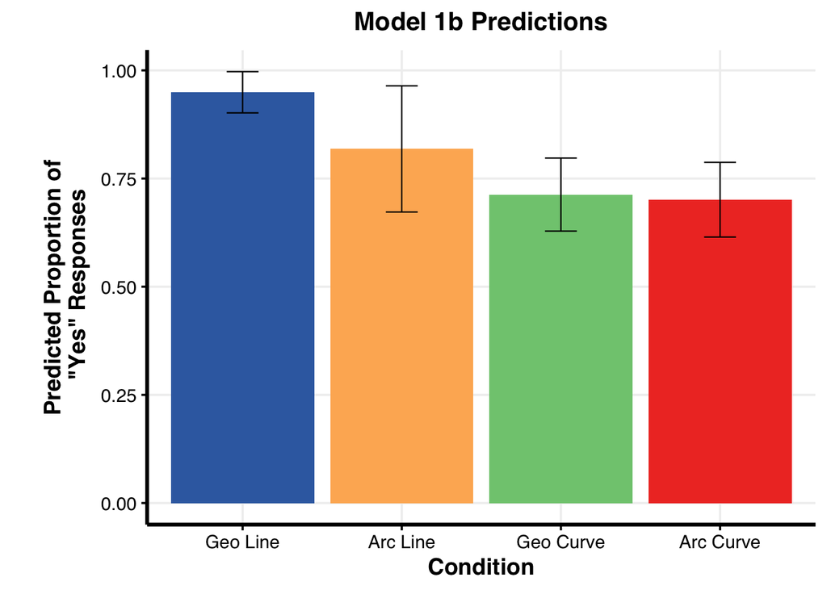

```r
model_1b_graph
```

### 3.3.2 Contrasts

We now look at the contrasts in order to explore which differences between categories are significant. All contrasts are holm-adjusted to correct for multiple comparisons.

```r
# Compute contrasts
contrast(
  object = model_1b_predicted,
  method = "pairwise",
  by = c("planar"),
  adjust = "holm"
  ) %>%
  tidy() %>%
  mutate(
    p_value = round(p.value, 4),
    p_value_clean = clean_p_val(p.value),
    p_value_star = stars.pval(p.value)
    ) %>%
  rename(
    "odds_ratio" = odds.ratio,
    "std_error" = std.error
    ) %>%
  select(planar, everything(), -p.value, -z.ratio, -df) %>%
  kable()
```

| planar | contrast | odds_ratio | std_error | p_value | p_value_clean | p_value_star |
| --- | --- | --- | --- | --- | --- | --- |
| curve | arc / geo | 0.9443698 | 0.0880578 | 0.5393 | 0.539 |  |
| line | arc / geo | 0.2400595 | 0.0334526 | 0.0000 | p < 0.001 | *** |

Participants say “yes” to pictures of curves on spheres equally frequently for arcs and geodesics, but are able to discriminate between the two categories for lines on spheres.

## 3.4 Model 2

We now move onto our second preregistered model, which just looks at spheres. This model goes beyond the properties of the surface and explores other properties, such as the length of the path and the size of the sphere.

In the preregistration document, Model 2 was based on the following equation:

```r
# Not run
glmer(
  formula = response ~ planar * spherical + size + line_length + pull +
    planar * pull + spherical * pull + (1 + planar | subject_no),
  family = binomial(link = "logit"),
  glmerControl(optimizer = "optimx", optCtrl = list(method = "nlminb"))
)
```

We predicted that `pull`—which controls the distance of the center of the curve from the equator—might affect accuracy. That is, we anticipated that participants would give more incorrect answers for paths that are far from the equator. In addition, we predicted that there might be a `Pull x Spherical` interaction with `pull` making geodesics harder to identify and arcs easier to identify.

However, this model failed to converge. We therefore removed the random slope for the planar condition, and also eliminated the `planar * pull` and `planar * spherical` interaction terms because they were not needed to address our registered hypotheses. Moreover, due to confusion about ambiguous variable names, we renamed `pull` to `rotation_angle`. Thus, the updated Model 2 is the following:

```r
model_2 <- IGEO_data %>%
  filter(surface == "sphere") %>%
  glmer(
    data = .,
    formula = response ~ size + line_length + planar +
      spherical * rotation_angle + (1 | subject_no),
    family = binomial(link = "logit"),
    glmerControl(optimizer = "optimx", optCtrl = list(method = "nlminb"))
    )

clean_IGEO_model(
  model = model_2,
  col_names = c("Intercept", "Size", "Line Length", "Rotation Angle",
    "Spherical", "Planar", "Rotation Angle x Spherical")
)
```

| term | log_odds | std_error | statistic | conf_lower | conf_upper | p_value | p_value_clean | p_value_star |
| --- | --- | --- | --- | --- | --- | --- | --- | --- |
| Intercept | -0.5265193 | 0.0928182 | -5.6725857 | -0.7084397 | -0.3445989 | 0.0000 | p < 0.001 | *** |
| Size | -0.0603213 | 0.0293292 | -2.0566991 | -0.1178054 | -0.0028372 | 0.0397 | p < 0.05 | * |
| Line Length | 0.0051930 | 0.0170022 | 0.3054314 | -0.0281307 | 0.0385167 | 0.7600 | 0.76 |  |
| Rotation Angle | 0.0001871 | 0.0801997 | 0.0023331 | -0.1570015 | 0.1573757 | 0.9981 | 0.998 |  |
| Spherical | 1.8076984 | 0.0761220 | 23.7473984 | 1.6585022 | 1.9568947 | 0.0000 | p < 0.001 | *** |
| Planar | -0.1617829 | 0.1586418 | -1.0198001 | -0.4727152 | 0.1491493 | 0.3078 | 0.308 |  |
| Rotation Angle x Spherical | -1.2617177 | 0.2585300 | -4.8803529 | -1.7684272 | -0.7550082 | 0.0000 | p < 0.001 | *** |

We predicted that `Rotation Angle`—which controls the distance of the center of the curve from the equator—might affect accuracy. That is, we anticipated that participants would give more incorrect answers for paths that are far from the equator. In addition, we predicted that there might be a `Rotation Angle x Spherical` interaction with `Rotation Angle` making geodesics harder to identify and arcs easier to identify.

Contrary to our prediction, `Rotation Angle` by itself did not significantly affect accuracy. However, there was a significant `Rotation Angle x Spherical` interaction. Given the negative coefficient, we interpret this as saying that for higher values of `Rotation Angle` and for geodesics, participants are less likely to answer correctly. This supports our hypothesis that `Rotation Angle` makes geodesics more difficult to identify and arcs easier to identify.

We also note that there is a significant effect of `Size` with a negative coefficent, implying that answers are more accurate for smaller spheres.

### 3.4.1 Simple Slopes for Model 2

Let’s explore in further detail the effect of `rotation_angle` on each of the levels of `spherical` by looking at the magnitude of `rotation_angle`’s effect on geodesics vs. arcs.

```r
IGEO_data %>%
  filter(surface == "sphere") %>%
  mutate(
    rotation_angle_centered = scale(rotation_angle, scale = FALSE),
    rotation_angle_geo = rotation_angle_centered*(spherical == "geo"),
    rotation_angle_arc = rotation_angle_centered*(spherical == "arc")
    ) %>%
  glmer(
    data = .,
    formula = response ~ size + line_length + planar +
      spherical + rotation_angle_geo + rotation_angle_arc + (1 | subject_no),
    family = binomial(link = "logit"),
    glmerControl(optimizer = "optimx", optCtrl = list(method = "nlminb"))
  ) %>%
  clean_IGEO_model(
    model = .,
    col_names = c("Intercept", "Size", "Line Length", "Planar", "Spherical",
      "Rotation Angle on Geos", "Rotation Angle on Arcs")
  )
```

| term | log_odds | std_error | statistic | conf_lower | conf_upper | p_value | p_value_clean | p_value_star |
| --- | --- | --- | --- | --- | --- | --- | --- | --- |
| Intercept | -0.5523118 | 0.0858003 | -6.4371776 | -0.7204772 | -0.3841463 | 0.0000 | p < 0.001 | *** |
| Size | -0.0603224 | 0.0293292 | -2.0567365 | -0.1178065 | -0.0028383 | 0.0397 | p < 0.05 | * |
| Line Length | 0.0051940 | 0.0170022 | 0.3054901 | -0.0281297 | 0.0385177 | 0.7600 | 0.76 |  |
| Planar | 0.0001959 | 0.0801980 | 0.0024428 | -0.1569894 | 0.1573812 | 0.9981 | 0.998 |  |
| Spherical | 1.6066514 | 0.0604785 | 26.5656786 | 1.4881158 | 1.7251871 | 0.0000 | p < 0.001 | *** |
| Rotation Angle on Geos | -1.4234891 | 0.2509110 | -5.6732827 | -1.9152657 | -0.9317126 | 0.0000 | p < 0.001 | *** |
| Rotation Angle on Arcs | -0.1617745 | 0.1586340 | -1.0197966 | -0.4726915 | 0.1491426 | 0.3078 | 0.308 |  |

In keeping with our predictions and previous observations, we see that `rotation_angle` differentially affects geodesicss vs. arcs. Increased `rotation_angle` makes geodesics significantly harder to identify, though there was no significant effect for arcs.

Note that we would obtain a qualitatively identical outcome if we examined the height of the points on the depicted sphere instead of the calculated rotaion angle. The angle of rotation and the height, while not precisely equal, are related by a simple `sin()` or `cos()` function. We will examine this in the next section.

### 3.4.2 Model 2 With Height

We now modify Model 2 slightly by looking at the absolute height of the points (where 0 means on the equator and 1 means at the north or south pole) instead of the rotation angle.

```r
model_2_height <- IGEO_data %>%
  filter(surface == "sphere") %>%
  glmer(
    data = .,
    formula = response ~ size + line_length + planar +
      spherical * height + (1 | subject_no),
    family = binomial(link = "logit"),
    glmerControl(optimizer = "optimx", optCtrl = list(method = "nlminb"))
    )

clean_IGEO_model(
  model = model_2_height,
  col_names = c("Intercept", "Size", "Line Length", "Height",
    "Spherical", "Planar", "Height x Spherical")
)
```

| term | log_odds | std_error | statistic | conf_lower | conf_upper | p_value | p_value_clean | p_value_star |
| --- | --- | --- | --- | --- | --- | --- | --- | --- |
| Intercept | -0.5654414 | 0.0983158 | -5.7512768 | -0.7581368 | -0.3727459 | 0.0000 | p < 0.001 | *** |
| Size | -0.0500451 | 0.0292608 | -1.7103099 | -0.1073952 | 0.0073051 | 0.0872 | 0.087 | . |
| Line Length | -0.0093094 | 0.0170967 | -0.5445151 | -0.0428182 | 0.0241994 | 0.5861 | 0.586 |  |
| Height | 0.0560526 | 0.0737189 | 0.7603570 | -0.0884337 | 0.2005390 | 0.4470 | 0.447 |  |
| Spherical | 1.8072695 | 0.0938449 | 19.2580464 | 1.6233369 | 1.9912022 | 0.0000 | p < 0.001 | *** |
| Planar | 0.0559835 | 0.1967963 | 0.2844741 | -0.3297302 | 0.4416971 | 0.7760 | 0.776 |  |
| Height x Spherical | -1.5756126 | 0.3834160 | -4.1094071 | -2.3270943 | -0.8241310 | 0.0000 | p < 0.001 | *** |

```r
IGEO_data %>%
  filter(surface == "sphere") %>%
  mutate(
    height_centered = scale(height, scale = FALSE),
    height_geo = height_centered*(spherical == "geo"),
    height_arc = height_centered*(spherical == "arc")
    ) %>%
  glmer(
    data = .,
    formula = response ~ size + line_length + planar +
      spherical + height_geo + height_arc + (1 | subject_no),
    family = binomial(link = "logit"),
    glmerControl(optimizer = "optimx", optCtrl = list(method = "nlminb"))
  ) %>%
  clean_IGEO_model(
    model = .,
    col_names = c("Intercept", "Size", "Line Length", "Planar", "Spherical",
      "Height on Geos", "Height on Arcs")
  )
```

| term | log_odds | std_error | statistic | conf_lower | conf_upper | p_value | p_value_clean | p_value_star |
| --- | --- | --- | --- | --- | --- | --- | --- | --- |
| Intercept | -0.5542562 | 0.0866871 | -6.3937581 | -0.7241598 | -0.3843527 | 0.0000 | p < 0.001 | *** |
| Size | -0.0500468 | 0.0292607 | -1.7103768 | -0.1073968 | 0.0073031 | 0.0872 | 0.087 | . |
| Line Length | -0.0093090 | 0.0170966 | -0.5444969 | -0.0428177 | 0.0241996 | 0.5861 | 0.586 |  |
| Planar | 0.0560316 | 0.0737131 | 0.7601306 | -0.0884434 | 0.2005065 | 0.4472 | 0.447 |  |
| Spherical | 1.4931456 | 0.0627165 | 23.8078483 | 1.3702235 | 1.6160677 | 0.0000 | p < 0.001 | *** |
| Height on Geos | -1.5197459 | 0.3100351 | -4.9018517 | -2.1274035 | -0.9120884 | 0.0000 | p < 0.001 | *** |
| Height on Arcs | 0.0560116 | 0.1967695 | 0.2846559 | -0.3296496 | 0.4416728 | 0.7759 | 0.776 |  |

Here we see a small difference between `height` and `rotation_angle`, in the sign of the non-effect of height on arcs. But because this term is not significant either way, we interpret this variation as being due to chance.

We can now plot the height vs. accuracy to better see how `height` differentially affects geodesics and arcs:

**Height plot code**

```r
# Turn height responses into bins for plotting
height_descriptives <- IGEO_data %>%
  filter(surface == "sphere") %>%
  group_by(height, spherical) %>%
  summarise(percent_correct = mean(as.numeric(response)) - 1) %>%
  ungroup(height, spherical) %>%
  mutate(bins = cut(height, 20)) %>%
  group_by(bins, spherical) %>%
  summarise(correct = mean(percent_correct)) %>%
  ungroup(bins, spherical) %>%
  separate(bins, c("pre_comma", "post_comma"), sep = ",") %>%
  mutate(
    pre_comma = as.numeric(str_remove(pre_comma, fixed("("))),
    post_comma = as.numeric(str_remove(post_comma, fixed("]"))),
    height = (pre_comma + post_comma)/2
  ) %>%
  select(height, spherical, correct)

my_labs <- function(){
  labs(
    x = "Height",
    y = "Accuracy",
    color = " ",
    title = "The Effect of Height on Accuracy"
  )
}

height_plot <- height_descriptives %>%
  mutate(spherical = factor(spherical, labels = c("Arc", "Geodesic")),
    spherical = fct_relevel(spherical, "Geodesic", "Arc")) %>%
  ggplot(data = ., aes(x = height, y = correct, color = spherical)) +
  geom_jitter() + scale_y_continuous(limits = c(0, 0.85)) +
  scale_x_continuous(limits = c(0, 0.81)) +
  IGEO_theme() + IGEO_colors() + my_labs()
```

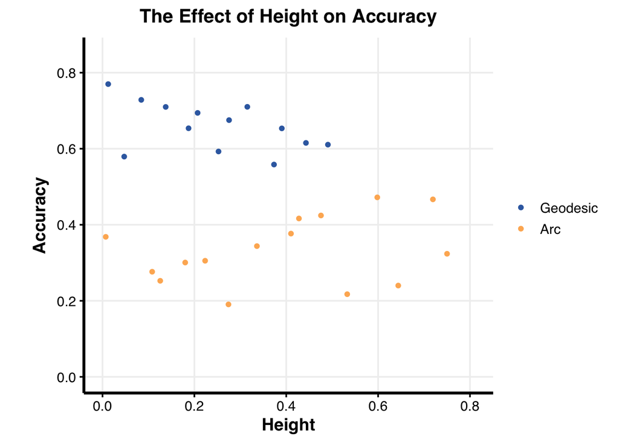

```r
height_plot
```

Note that, as per our model, there is a consistent downward trend for geodesics, but less of a clear trend for arcs (hence why the latter is not significant). This accounts for the significant `Height x Spherical` interaction effect.

# References

Dillon, M., & Spelke, E. (2018). From map reading to geometric intuitions. *Developmental Psychology, 54(7)*, 1304–1316.

Euclid. (1990). *Great Books of the Western World: The thirteen books of Euclid’s* Elements. *The works of Archimedes, including* The Method.* Introduction to *Arithmetic* by Nicomachus* (2 ed.). Chicago: Encyclopedia Britannica. (Original work written 300 B.C.E.).

Hart, Y., Dillon, M., Marantan, A., Cardenas, A., Spelke, E., & Mahadevan. (2018). The statistical shape of geometric reasoning. *Scientific Reports, 8(1)*, 12906.

Izard, V., Pica, P., Spelke, E. S., & Dehaene, S. (2011). Flexible intuitions of Euclidean geometry in an Amazonian indigene group. *Proceedings of the National Academy of Sciences of the United States of America, 108(24)*, 9782-9787.